# TateyamaForest_1368_1459_correct

Ishida M

2026-10-01

# mail

Dear Jayalakshmi,

Thank you very much for your help with the production of our article.

Article ID: JVS_70175 Article DOI: 10.1111/JVS.70175 Manuscript Reference ID: 5217335

During proof checking, we found an error in the elevation of the meteorological observation site. The paper states 1,368 m, but the correct figure is 1,459 m. We do not expect the main conclusions to change, but several results derived from this value, including the warmth index, will need to be revised.

Because these revisions go beyond typical proof corrections, we are unlikely to meet today’s 6:00 PM (JST) deadline. We would therefore like to ask you to put the proof on hold. If necessary, we would be grateful if you could consult the handling editor on whether the revised results require editorial review before publication.

We are working urgently on the revisions and will send the corrected text, together with the other proof corrections from the co-authors, as soon as possible. We apologize for the inconvenience.

Best regards,

Megumi Ishida 28 September 2026

# correct Branch “alt_correct”

```r
system("git branch --show-current", intern = TRUE)
```

```
## [1] "alt_correct"
```

```r
#library(package="TateyamaForest")
devtools::load_all("../../..")
```

# csv

[*] YearsIntervalCalc_plots_temp.csv (alt_correct.R)

# RData

## wi RData

```r
fl<-read.csv("../old_RData.csv")
fl
```

| file | object | source | paper | status | note | class | dim |
| --- | --- | --- | --- | --- | --- | --- | --- |
| Abies_death_ratio_wi.RData | Abies_death_ratio | NA | NA | todo | NA | list | 3 |
| data_Abies_death_ratio_wi.RData | data_Abies_death_ratio_wi | NA | NA | todo | NA | data.frame | 21 x 4 |
| TemperatureWIAbies_Population_BA_Mortality.RData | TemperatureWIAbies_Population_BA_Mortality2 | NA | NA | todo | NA | data.frame | 18 x 18 |
| TemperatureWIAbiesPopulation.RData | TemperatureWIAbiesPopulation | NA | NA | todo | NA | data.frame | 18 x 15 |
| WI_with_KurodeDamObservation_1965_2024_AllForestPlots.RData | WI_with_KurodeDamObservation_1965_2024_AllForestPlots | NA | NA | todo | NA | data.frame | 60 x 9 |
| WI_with_KurodeDamObservation.RData | WI_with_KurodeDamObservation | NA | NA | todo | NA | data.frame | 60 x 5 |
| wi_yaer.RData | wi_yaer | NA | NA | todo | NA | data.frame | 60 x 5 |
| wi_year.RData | wi_year | NA | NA | todo | NA | data.frame | 60 x 5 |
| yr_wi_bar.RData | yr_wi_bar | NA | NA | todo | NA | data.frame | 28 x 6 |

```r
knitr::kable(fl)
```

| file | object | source | paper | status | note | class | dim |
| --- | --- | --- | --- | --- | --- | --- | --- |
| Abies_death_ratio_wi.RData | Abies_death_ratio | NA | NA | todo | NA | list | 3 |
| data_Abies_death_ratio_wi.RData | data_Abies_death_ratio_wi | NA | NA | todo | NA | data.frame | 21 x 4 |
| TemperatureWIAbies_Population_BA_Mortality.RData | TemperatureWIAbies_Population_BA_Mortality2 | NA | NA | todo | NA | data.frame | 18 x 18 |
| TemperatureWIAbiesPopulation.RData | TemperatureWIAbiesPopulation | NA | NA | todo | NA | data.frame | 18 x 15 |
| WI_with_KurodeDamObservation_1965_2024_AllForestPlots.RData | WI_with_KurodeDamObservation_1965_2024_AllForestPlots | NA | NA | todo | NA | data.frame | 60 x 9 |
| WI_with_KurodeDamObservation.RData | WI_with_KurodeDamObservation | NA | NA | todo | NA | data.frame | 60 x 5 |
| wi_yaer.RData | wi_yaer | NA | NA | todo | NA | data.frame | 60 x 5 |
| wi_year.RData | wi_year | NA | NA | todo | NA | data.frame | 60 x 5 |
| yr_wi_bar.RData | yr_wi_bar | NA | NA | todo | NA | data.frame | 28 x 6 |

# Manuscript

## 1368m.png

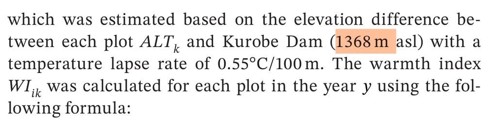

### response OK!! 5.docx

## eq1

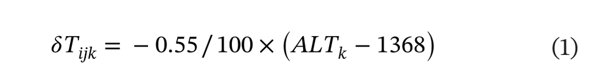

### response OK!! 5.docx

## Fig04.png

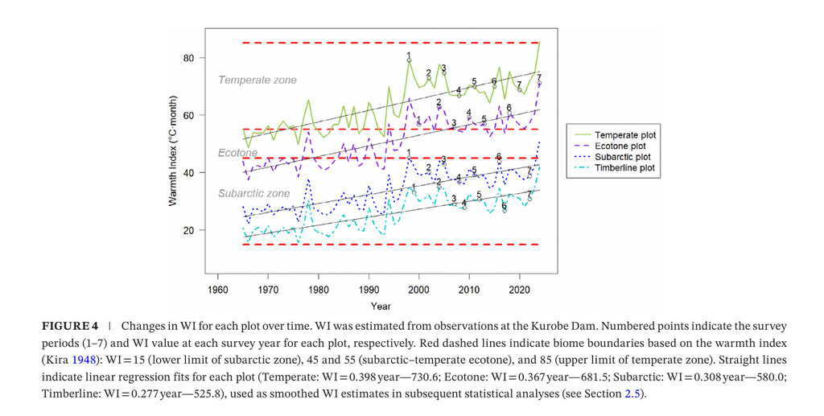

### response

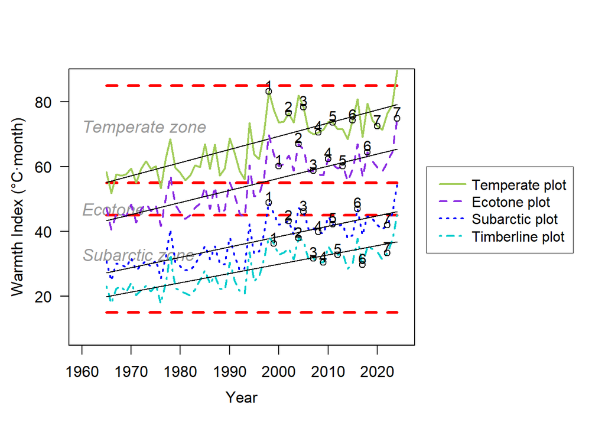

```r
res<-Fig_year_WI_3()
```

```r
res
```

```
## $Bunazaka
##
## Call:
## lm(formula = y ~ x)
##
## Coefficients:
## (Intercept)            x
##   -746.1447       0.4078
##
##
## $Kaminokodaira
##
## Call:
## lm(formula = y ~ x)
##
## Coefficients:
## (Intercept)            x
##    -693.586        0.375
##
##
## $Matsuotoge
##
## Call:
## lm(formula = y ~ x)
##
## Coefficients:
## (Intercept)            x
##   -601.2193       0.3199
##
##
## $Kagamiishi
##
## Call:
## lm(formula = y ~ x)
##
## Coefficients:
## (Intercept)            x
##   -542.6755       0.2863
```

## WI-increased.png

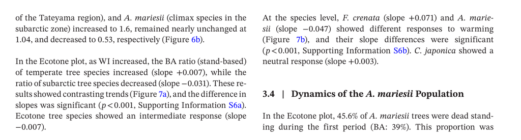

## Fig7.png

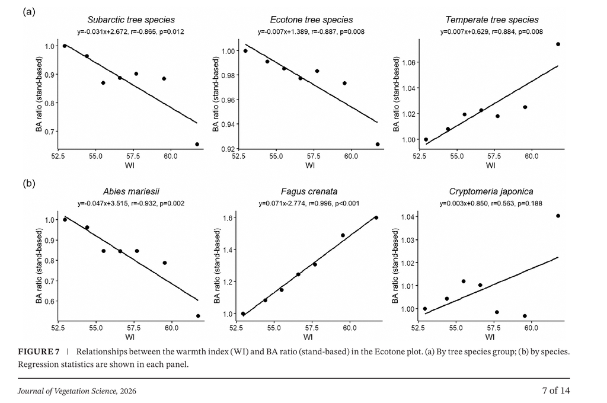

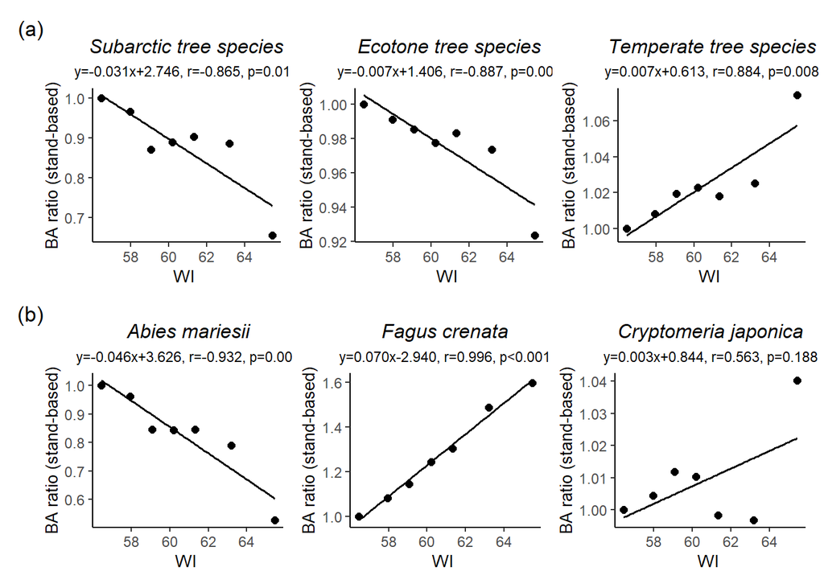

```r
 # .data_Fig_yr_ba_kaminokodaira_zone_2024
 # .data_Fig_yr_ba_kaminokodaira_Cryptomeria_Fagus_Abies_2024

res<-Fig_wi_ba_cor_ancova_JVS2()
```

```r
res
```

```
## $slopes
##                             label                     sp        slope
## Temperate tree species    By zone Temperate tree species  0.006796890
## Ecotone tree species      By zone   Ecotone tree species -0.007103491
## Subarctic tree species    By zone Subarctic tree species -0.030821347
## Fagus crenata          By species          Fagus crenata  0.069506647
## Cryptomeria japonica   By species   Cryptomeria japonica  0.002729859
## Abies mariesii         By species         Abies mariesii -0.046186835
##
## $pairwise
##                                         comparison slope_ref slope_other
## 1   Temperate tree species vs Ecotone tree species   0.00680    -0.00710
## 2 Temperate tree species vs Subarctic tree species   0.00680    -0.03082
## 3   Ecotone tree species vs Subarctic tree species  -0.00710    -0.03082
## 4            Fagus crenata vs Cryptomeria japonica   0.06951     0.00273
## 5                  Fagus crenata vs Abies mariesii   0.06951    -0.04619
## 6           Cryptomeria japonica vs Abies mariesii   0.00273    -0.04619
##   slope_diff t_value p_value      label
## 1   -0.01390  -2.046  0.0587    By zone
## 2   -0.03762  -5.538  0.0001    By zone
## 3   -0.02372  -3.492  0.0033    By zone
## 4   -0.06678  -9.381  0.0000 By species
## 5   -0.11569 -16.253  0.0000 By species
## 6   -0.04892  -6.872  0.0000 By species
```

## WI-regression.png

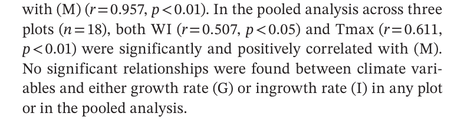

## WI-ANCOVA

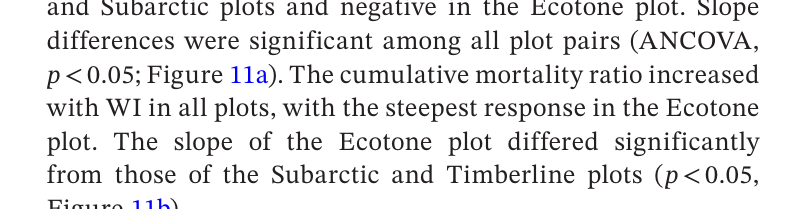

## WItrend3

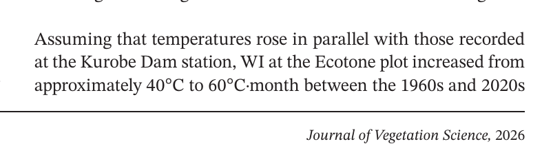

## 3-1-change in WI

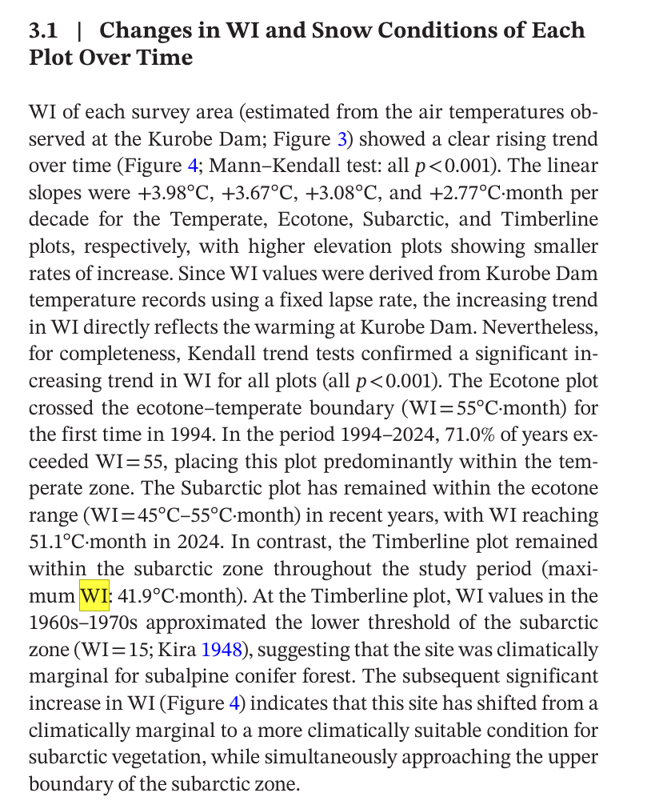

## EcotonePlot-WI

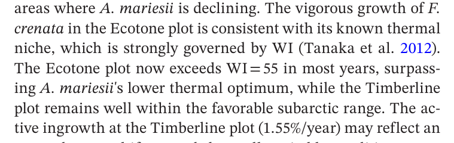

## WItrend

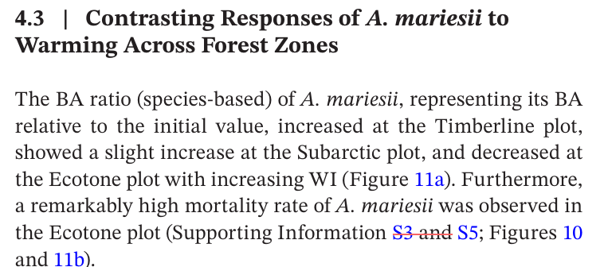

## Fig11

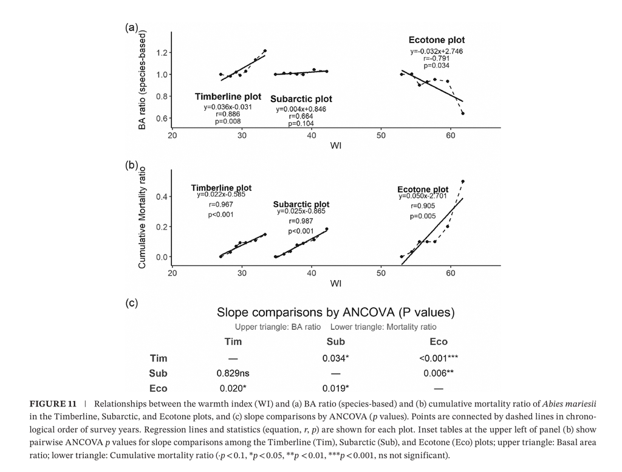

```r
Abies
```

|  | plot | year | BAratio | mortality | WI | WI1368 |
| --- | --- | --- | --- | --- | --- | --- |
| 36 | Kaminokodaira | 2000 | 1.0000000 | 0.00000000 | 56.45196 | 52.92710 |
| 40 | Kaminokodaira | 2004 | 1.0023957 | 0.03333333 | 57.95204 | 54.39599 |
| 43 | Kaminokodaira | 2007 | 0.9006119 | 0.10000000 | 59.07710 | 55.49766 |
| 46 | Kaminokodaira | 2010 | 0.9314482 | 0.10000000 | 60.20215 | 56.59932 |
| 49 | Kaminokodaira | 2013 | 0.9520498 | 0.10000000 | 61.32721 | 57.70099 |
| 54 | Kaminokodaira | 2018 | 0.9358946 | 0.20000000 | 63.20231 | 59.53710 |
| 60 | Kaminokodaira | 2024 | 0.6415239 | 0.50000000 | 65.45242 | 61.74043 |
| 34 | Matsuotoge | 1998 | 1.0000000 | 0.00000000 | 37.84652 | 34.80163 |
| 38 | Matsuotoge | 2002 | 1.0101878 | 0.01785714 | 39.12593 | 36.03244 |
| 41 | Matsuotoge | 2005 | 1.0088253 | 0.03571429 | 40.08549 | 36.95554 |

[output cut: 11 more lines]

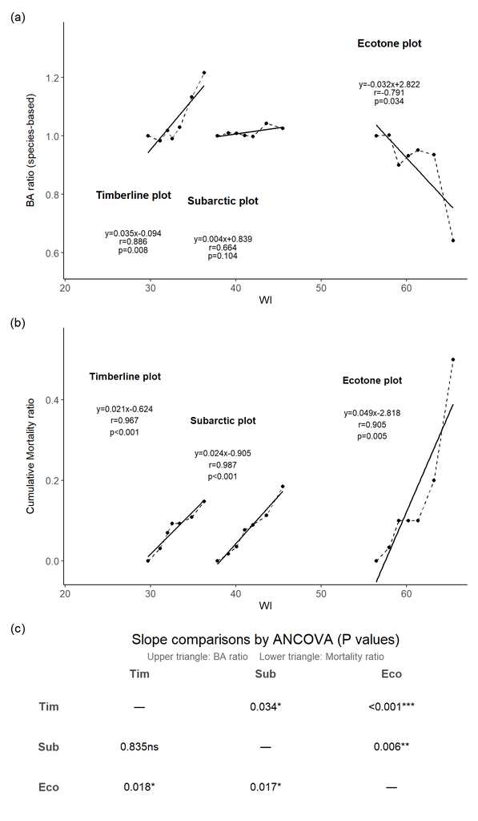

```r
res <- Fig_Abies_wi_ba_mortality()
```

```r
res
```

```
## $regression_ba
##              plot                          reg_label    x y_name y_reg
## 1    Ecotone plot y=-0.032x+2.822\nr=-0.791\np=0.034 58.0   1.32  1.15
## 2  Subarctic plot   y=0.004x+0.839\nr=0.664\np=0.104 38.5   0.78  0.62
## 3 Timberline plot   y=0.035x-0.094\nr=0.886\np=0.008 28.0   0.80  0.64
##
## $regression_mortality
##              plot                        reg_label    x y_name y_reg
## 1    Ecotone plot y=0.049x-2.818\nr=0.905\np=0.005 56.0   0.45  0.34
## 2  Subarctic plot y=0.024x-0.905\nr=0.987\np<0.001 38.5   0.35  0.24
## 3 Timberline plot y=0.021x-0.624\nr=0.967\np<0.001 27.0   0.46  0.35
##
## $BAratio_ancova
## $BAratio_ancova$pw
##                          comparison slope_ref slope_other slope_diff t_value
## 1 Timberline plot vs Subarctic plot   0.03492     0.00419   -0.03072  -2.337
## 2   Timberline plot vs Ecotone plot   0.03492    -0.03161   -0.06652  -5.374
## 3    Subarctic plot vs Ecotone plot   0.00419    -0.03161   -0.03580  -3.210
##   p_value
## 1  0.0337
## 2  0.0001
## 3  0.0058
##
## $BAratio_ancova$mat
##                 Timberline plot Subarctic plot Ecotone plot
## Timberline plot "—"             "0.034*"       "<0.001***"
## Subarctic plot  "0.034*"        "—"            "0.006**"
## Ecotone plot    "<0.001***"     "0.006**"      "—"
##
##
## $mortality_ancova
## $mortality_ancova$pw
##                          comparison slope_ref slope_other slope_diff t_value
## 1 Timberline plot vs Subarctic plot   0.02135     0.02369    0.00234   0.212
## 2   Timberline plot vs Ecotone plot   0.02135     0.04901    0.02766   2.654
## 3    Subarctic plot vs Ecotone plot   0.02369     0.04901    0.02532   2.696
##   p_value
## 1  0.8353
## 2  0.0181
## 3  0.0166
##
## $mortality_ancova$mat
##                 Timberline plot Subarctic plot Ecotone plot
## Timberline plot "—"             "0.835ns"      "0.018*"
## Subarctic plot  "0.835ns"       "—"            "0.017*"
## Ecotone plot    "0.018*"        "0.017*"       "—"
```

## WItrend2

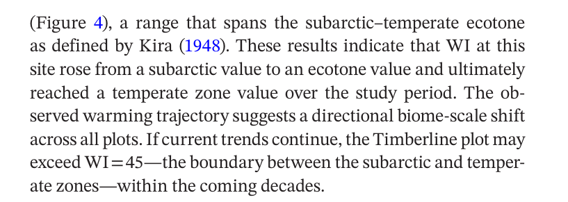

## S6

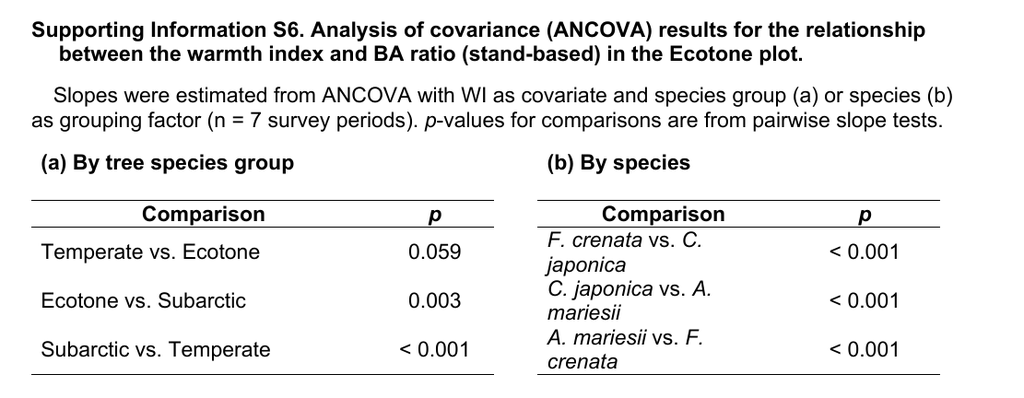

```r
  s <- new_statistics(
    wi_year          = wi_year,
    Abies_death_ratio = Abies_death_ratio,
    f1_raw           = data_Fig_yr_ba_kaminokodaira_Cryptomeria_Fagus_Abies_2024,
    f2_raw           = data_Fig_yr_ba_kaminokodaira_zone_2024
  )

  print(s)
```

```
## $wi
##      year Bunazaka Kaminokodaira Matsuotoge Kagamiishi
## 1965 1965  58.4410       47.2210    30.8675    23.1675
## 1966 1966  51.8410       40.6210    24.8675    17.7740
## 1967 1967  57.6145       45.3210    30.1675    22.4675
## 1968 1968  57.2145       45.6210    29.9675    23.0740
## 1969 1969  57.7145       44.8210    28.9675    21.2675
## 1970 1970  59.5410       48.3210    31.8675    24.1675
## 1971 1971  55.0145       42.8175    27.9675    20.2675
## 1972 1972  59.3145       46.8210    29.5675    21.8675
## 1973 1973  61.7145       48.6245    30.8675    23.1740
## 1974 1974  59.3145       46.2245    29.2675    21.5675
## 1975 1975  60.1145       48.1210    31.1675    23.5740
## 1976 1976  53.3145       41.7210    25.5675    17.8675
## 1977 1977  62.7145       50.1210    32.3010    23.9675
```

[output cut: 132 more lines]

## ANCOVA: BAratio ~ WI * species/zone

```r
res4 <- statistics_ANCOVA_wi_ba_EcotonePlot(s)
```

```
## ANCOVA: BA ratio ~ WI * species/zone
```

```
##
## --- By species ---
##
## Call:
## lm(formula = ba_ratio ~ WI * sp, data = data)
##
## Residuals:
##       Min        1Q    Median        3Q       Max
## -0.076933 -0.016967  0.000529  0.013190  0.081801
##
## Coefficients:
##                            Estimate Std. Error t value Pr(>|t|)
## (Intercept)               -2.940489   0.304974  -9.642 8.06e-08 ***
## WI                         0.069507   0.005033  13.809 6.20e-10 ***
## spCryptomeria japonica     3.784147   0.431298   8.774 2.71e-07 ***
## spAbies mariesii           6.566610   0.431298  15.225 1.57e-10 ***
## WI:spCryptomeria japonica -0.066777   0.007118  -9.381 1.15e-07 ***
## WI:spAbies mariesii       -0.115693   0.007118 -16.253 6.22e-11 ***
## ---
## Signif. codes:  0 '***' 0.001 '**' 0.01 '*' 0.05 '.' 0.1 ' ' 1
##
## Residual standard error: 0.03817 on 15 degrees of freedom
## Multiple R-squared:   0.98,  Adjusted R-squared:  0.9734
## F-statistic: 147.2 on 5 and 15 DF,  p-value: 3.392e-12
##
## --- Slope of each group ---
##   Fagus crenata                0.06951 /WI
##   Cryptomeria japonica         0.00273 /WI
##   Abies mariesii               -0.04619 /WI
##
## --- Pairwise slope comparisons (ba_ratio ~ WI) ---
##                               comparison slope_ref slope_other slope_diff
## 1  Fagus crenata vs Cryptomeria japonica   0.06951     0.00273   -0.06678
## 2        Fagus crenata vs Abies mariesii   0.06951    -0.04619   -0.11569
## 3 Cryptomeria japonica vs Abies mariesii   0.00273    -0.04619   -0.04892
##   t_value p_value
## 1  -9.381       0
## 2 -16.253       0
## 3  -6.872       0
##
```

[output cut: 23 more lines]

```
##
## --- Slope of each group ---
##   Temperate tree species       0.00680 /WI
##   Ecotone tree species         -0.00710 /WI
##   Subarctic tree species       -0.03082 /WI
##
## --- Pairwise slope comparisons (ba_ratio ~ WI) ---
##                                         comparison slope_ref slope_other
## 1   Temperate tree species vs Ecotone tree species    0.0068    -0.00710
## 2 Temperate tree species vs Subarctic tree species    0.0068    -0.03082
## 3   Ecotone tree species vs Subarctic tree species   -0.0071    -0.03082
##   slope_diff t_value p_value
## 1   -0.01390  -2.046  0.0587
## 2   -0.03762  -5.538  0.0001
## 3   -0.02372  -3.492  0.0033
```

```r
res4$by_species$slopes
```

```
##        Fagus crenata Cryptomeria japonica       Abies mariesii
##          0.069506647          0.002729859         -0.046186835
```

## ANCOVA: cumulative mortality ratio ~ year * plot

```r
res2 <- statistics_ANCOVA_Abies_CumulativeDeathRatio_year_plot(s)
```

```
## ANCOVA: cumulative mortality ~ year * plot
```

```
##
## Call:
## lm(formula = death_ratio ~ year * plot, data = s$death_data)
##
## Residuals:
##      Min       1Q   Median       3Q      Max
## -0.08700 -0.01029 -0.00093  0.01097  0.11083
##
## Coefficients:
##                       Estimate Std. Error t value Pr(>|t|)
## (Intercept)         -36.809434   4.595067  -8.011 8.47e-07 ***
## year                  0.018379   0.002285   8.043 8.06e-07 ***
## plotMatsuotoge       21.662900   6.495176   3.335  0.00452 **
## plotKagamiishi       24.601622   6.694107   3.675  0.00225 **
## year:plotMatsuotoge  -0.010802   0.003232  -3.343  0.00445 **
## year:plotKagamiishi  -0.012267   0.003330  -3.684  0.00221 **
## ---
## Signif. codes:  0 '***' 0.001 '**' 0.01 '*' 0.05 '.' 0.1 ' ' 1
##
## Residual standard error: 0.04621 on 15 degrees of freedom
## Multiple R-squared:  0.8616, Adjusted R-squared:  0.8154
## F-statistic: 18.67 on 5 and 15 DF,  p-value: 5.798e-06
##
##
## --- Slope of each plot ---
##   Kaminokodaira        0.018379 /yr
##   Matsuotoge           0.007577 /yr
##   Kagamiishi           0.006112 /yr
##
## --- Pairwise slope comparisons (death_ratio ~ year) ---
##                    comparison slope_ref slope_other slope_diff t_value p_value
## 1 Kaminokodaira vs Matsuotoge   0.01838     0.00758   -0.01080  -3.343  0.0045
## 2 Kaminokodaira vs Kagamiishi   0.01838     0.00611   -0.01227  -3.684  0.0022
## 3    Matsuotoge vs Kagamiishi   0.00758     0.00611   -0.00146  -0.440  0.6663
```

```r
res2$pairwise
```

| comparison | slope_ref | slope_other | slope_diff | t_value | p_value |
| --- | --- | --- | --- | --- | --- |
| Kaminokodaira vs Matsuotoge | 0.01838 | 0.00758 | -0.01080 | -3.343 | 0.0045 |
| Kaminokodaira vs Kagamiishi | 0.01838 | 0.00611 | -0.01227 | -3.684 | 0.0022 |
| Matsuotoge vs Kagamiishi | 0.00758 | 0.00611 | -0.00146 | -0.440 | 0.6663 |

## S7

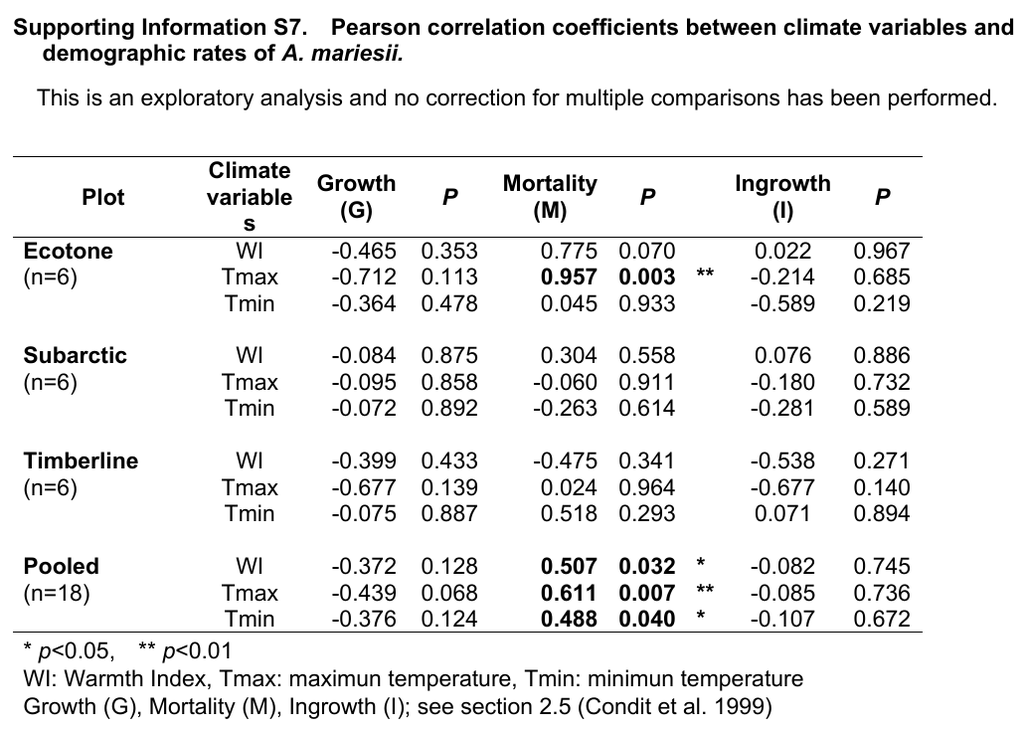

```r
tbl <- Table_TemperatureWIAbiesPopulation_cor()

knitr::kable(tbl) |>
  kableExtra::kable_styling(
    bootstrap_options = c("striped", "condensed"),
    font_size = 11,
    full_width = TRUE
  ) |>
  kableExtra::scroll_box(width = "100%")
```

variables

Ecotone (n=6)

WI

-0.910

0.0118

0.683

0.1345

-0.856

0.0295

Tmax

-0.712

0.1125

0.957

0.0027

-0.214

0.6845

Tmin

-0.364

0.4782

0.045

0.9325

-0.589

0.2188

Tmean

-0.660

0.1539

0.599

0.2092

-0.509

0.3020

Subarctic (n=6)

WI

-0.438

0.3854

0.044

0.9335

-0.623

0.1868

Tmax

-0.095

0.8583

-0.060

0.9106

-0.180

0.7323

Tmin

-0.072

0.8920

-0.263

0.6143

-0.281

0.5893

Tmean

-0.412

0.4172

0.069

0.8973

-0.568

0.2396

Timberline (n=6)

WI

0.147

0.7816

0.783

0.0655

0.370

0.4698

Tmax

-0.677

0.1393

0.024

0.9641

-0.677

0.1400

Tmin

-0.075

0.8871

0.518

0.2925

0.071

0.8936

Tmean

0.030

0.9548

0.807

0.0525

0.260

0.6194

Pooled (n=18)

WI

-0.392

0.1075

0.548

0.0186

-0.074

0.7715

Tmax

-0.439

0.0682

0.611

0.0071

-0.085

0.7359

Tmin

-0.376

0.1242

0.488

0.0398

-0.107

0.6717

Tmean

-0.464

0.0526

0.432

0.0736

-0.301

0.2251

## zendo.png

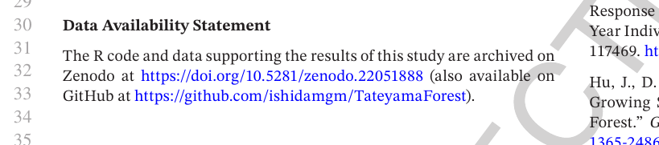